# Intervalos de confiança para a proporção

ProbEst

fnaufel

Criado em 02/02/2021 Versão de 17/09/2021

# 1 Exemplo: quem posta no FB diariamente?

## 1.1 Teoria

- Uma pesquisa com uma amostra aleatória de $156$ jovens descobriu que $48$ deles postam no FB todo dia.
- Qual a proporção amostral de jovens que postam no FB diariamente?

  ```r
  p_chapeu <- 48/156
  p_chapeu
  ```

  ```
  ## [1] 0,3076923
  ```

  A resposta é $\hat p = 0{,}31$, ou $31\%$.

  Perceba que é costume chamar a proporção amostral de $\hat p$.
- Isto quer dizer que a proporção populacional é $0{,}31$? Não necessariamente, mas esta parece ser uma boa estimativa.
- Existe uma *margem de erro*. Como computá-la? Usando o TCL!
- Primeiro, verificamos que as condições para usar o TCL são satisfeitas:
  - De fato, $n > 30$.
  - A nossa amostra é aleatória (podemos supor).
  - Os indivíduos da amostra são independentes (podemos supor).
  - O tamanho da amostra é menos do que $10\%$ da população (podemos supor).
  - Há pelo menos $10$ sucessos e pelo menos $10$ fracassos na amostra.
- A proporção amostral $\hat p$ varia para cada amostra; logo, $\hat p$ é uma variável aleatória e tem uma distribuição de probabilidade: a distribuição amostral da proporção.
- O TCL diz que a distribuição de $\hat p$ é normal, com média $p$ (a proporção populacional verdadeira, que nós nunca vamos descobrir) e desvio padrão $\sqrt{\frac{p(1-p)}{n}}$ (que também nunca vamos descobrir, mas que podemos estimar usando $\hat p$ no lugar de $p$).
- Vamos supor que $\hat p \neq p$. Eis, então, as duas situações possíveis:

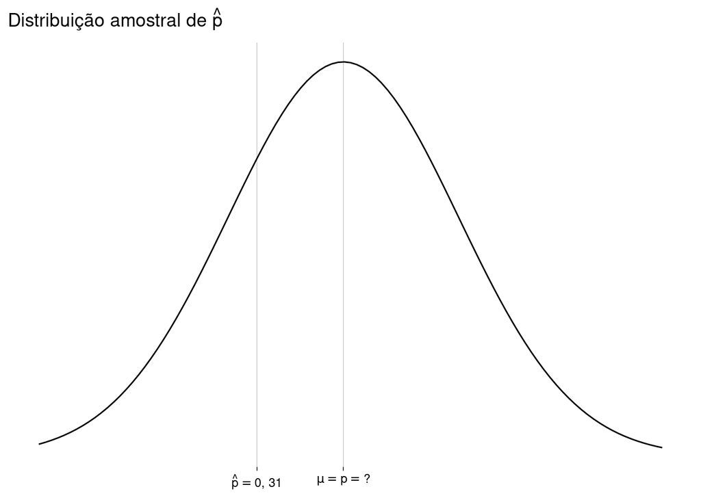

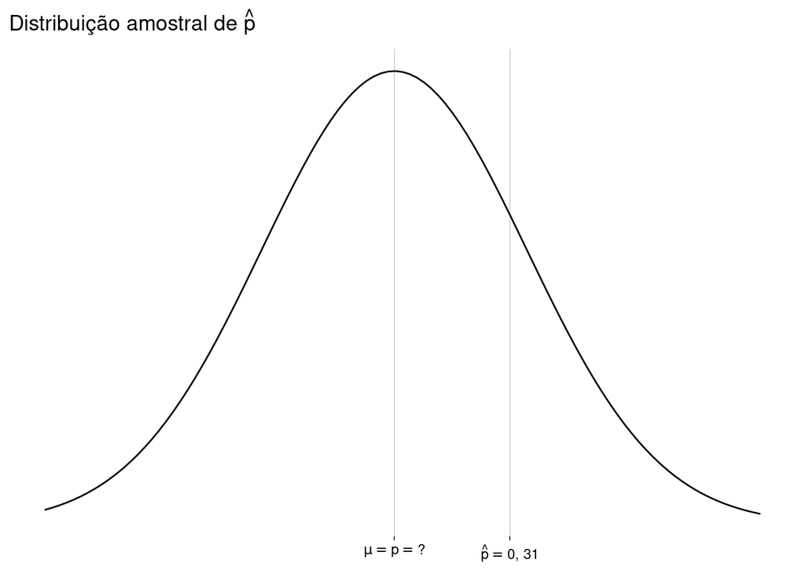

- Agora, o desfecho. Preste bem atenção. Nada nas mangas.
  - Em uma distribuição normal com média $\mu$ e desvio padrão $\sigma$, sabemos que $95\%$ da probabilidade está entre $\mu - 1{,}96\sigma$ e $\mu + 1{,}96\sigma$.

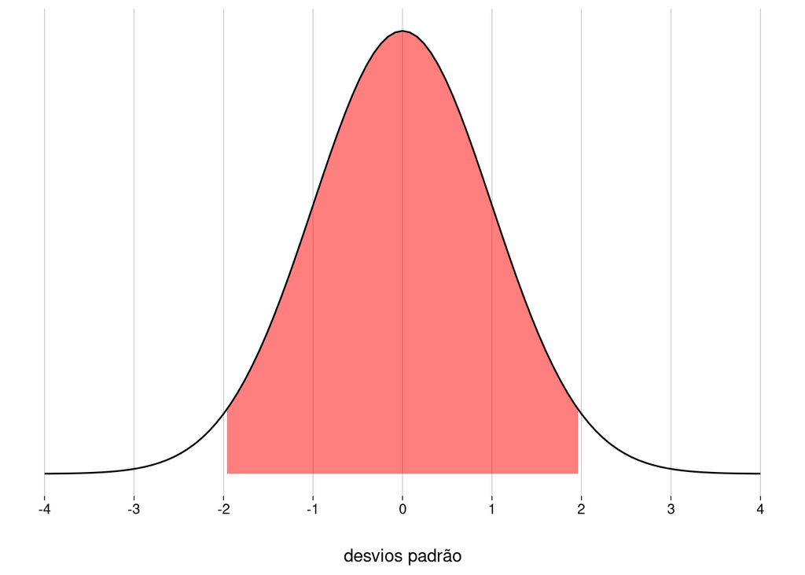

  - Na nossa distribuição amostral de $\hat p$, o desvio padrão é o erro padrão

    $$EP = \sqrt{\frac{\hat p(1-\hat p)}{n}}$$
  - Então, em $95\%$ das amostras possíveis, $\hat p$ vai estar a $1{,}96\cdot EP$ ou menos de distância da proporção populacional $p$.
  - Nossa amostra é uma destas $95\%$ das amostras possíveis? Não sabemos. Na verdade, como nossa amostra foi aleatória, há $0{,}95$ de probabilidade de que sim.
  - Ou seja, há $0{,}95$ de probabilidade de que nosso $\hat p$ esteja a $1{,}96\cdot EP$ ou menos de distância da proporção populacional $p$.
  - Daí, podemos dizer, com $95\%$ de confiança, que a proporção populacional $p$ está no intervalo

    $$[\quad \hat p - 1{,}96 \cdot EP\quad,\quad \hat p + 1{,}96 \cdot EP\quad]
    \quad=\quad
    [\quad0{,}24
    \quad,\quad
    0{,}38\quad]$$
- Eis os desenhos para as duas situações possíveis:

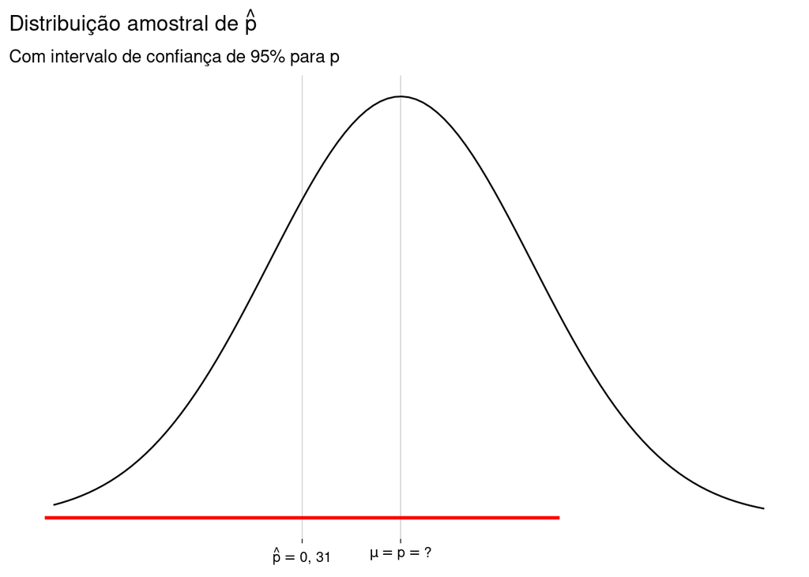

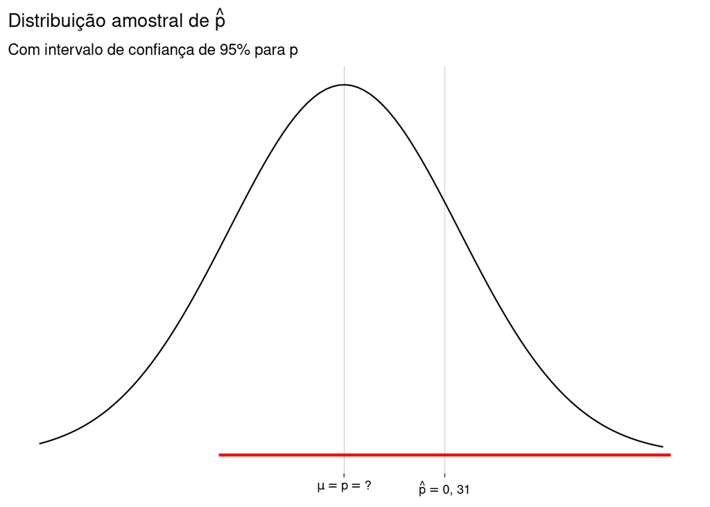

### O que quer dizer $\;95\%$ de confiança?

Quer dizer que não temos certeza de que nossa amostra está dentre aquelas cuja proporção amostral $\hat p$ está a $1{,}96$ desvios padrão ou menos de distância da proporção populacional $p$.

Existe $0{,}05$ de probabilidade de que nossa amostra tenha sido “ruim”. Neste caso, nosso intervalo de confiança está errado.

Ou, dito de outro modo, se repetirmos este experimento com $100$ amostras diferentes, o intervalo de confiança calculado vai conter a proporção populacional em $95$ das vezes.

É importante perceber que $95\%$ *não é* a probabilidade de $p$ estar no intervalo, pois $p$ é um valor fixo, sem qualquer incerteza, que está (probabilidade $1$) ou não está (probabilidade $0$) no nosso intervalo de confiança.

## 1.2 Simulação

- Vamos simular uma população de $200$ mil valores booleanos: `FALSE` significa que a pessoa não posta no FB todo dia, `TRUE` significa que a pessoa posta no FB todo dia.
- A proporção populacional $p$ que posta todo dia tem um valor específico, que não vou revelar aqui. Na vida real, você não vai saber o valor de $p$.

  ```r
  populacao <- sample(
    c(FALSE, TRUE),
    2e5,
    replace = TRUE,
    prob = c(1 - p, p)
  )
  ```

- Vamos retirar uma amostra de $156$ pessoas:

  ```r
  n <- 156
  amostra <- sample(populacao, n)
  ```

- Qual a proporção de pessoas que postam todo dia ($\hat p$)?

  ```r
  p_chapeu <- mean(amostra)
  p_chapeu
  ```

  ```
  ## [1] 0,3012821
  ```

- Vamos construir um intervalo de confiança de $95\%$ para a proporção populacional $p$:
  - O erro padrão é

    ```r
    ep <- sqrt(p_chapeu * (1 - p_chapeu) / n)
    ep
    ```

    ```
    ## [1] 0,0367346
    ```

  - Para $95\%$, precisamos usar $1{,}96$ como o número de desvios padrão. A margem de erro será

    ```r
    margem <- 1.96 * ep
    margem
    ```

    ```
    ## [1] 0,07199981
    ```

  - Os extremos do intervalo de confiança vão ser

    ```r
    p_chapeu + c(-1, 1) * margem
    ```

    ```
    ## [1] 0,2292822 0,3732819
    ```

- Será que este intervalo é bom? Será que a amostra que tomamos está naqueles $95\%$ de amostras que ficam próximas da proporção verdadeira? Será que a proporção verdadeira está neste intervalo?
- Na vida real, jamais saberíamos. Eu sei, porque fui eu que gerei a população, mas não vou falar ainda.
- Vamos gerar mais $50$ amostras e examinar os intervalos de confiança calculados a partir delas. Como estamos trabalhando com $95\%$ de confiança, é razoável que $2$ ou $3$ dos intervalos — i.e., $5\%$ de $50$ — não capturem a proporção real:

  ```r
  n_amostras <- 50

  # Gero uma lista, cada elemento uma amostra (um vetor)
  amostras <- replicate(n_amostras, sample(populacao, n), simplify = FALSE)

  #' Função para calcular o IC de uma amostra: retorna vetor de 2 elementos
  #' @param amostra Vetor booleanos
  #' @param conf Nível de confiança (default .95)
  #'
  #' @return Vetor numérico de 2 elementos: extremos do IC calculado
  #'
  montar_ic <- function(amostra, conf = .95) {

    p_chapeu <- mean(amostra)
    ep <- sqrt(p_chapeu * (1 - p_chapeu) / n)
    valor_critico <- - qnorm((1 - conf)/2)
    margem <- valor_critico * ep

    p_chapeu + c(-1, 1) * margem

  }

  # Calcular os ICs
  ICs <- amostras %>%
    map(~montar_ic(.x))

  # Em quais deles a proporção verdadeira está no IC?
  ICs %>%
    map_lgl(~between(p, .x[1], .x[2]))
  ```

  ```
  ##  [1]  TRUE  TRUE  TRUE  TRUE  TRUE  TRUE  TRUE  TRUE  TRUE  TRUE  TRUE  TRUE
  ## [13]  TRUE  TRUE  TRUE  TRUE  TRUE FALSE  TRUE  TRUE  TRUE  TRUE  TRUE  TRUE
  ## [25]  TRUE  TRUE  TRUE  TRUE  TRUE  TRUE  TRUE  TRUE  TRUE  TRUE  TRUE  TRUE
  ## [37]  TRUE  TRUE  TRUE  TRUE FALSE  TRUE  TRUE  TRUE FALSE  TRUE  TRUE  TRUE
  ## [49]  TRUE  TRUE
  ```

- Verifique, no resultado acima, se a proporção verdadeira foi capturada aproximadamente $95\%$ das vezes.
- Uma visualização legal dos intervalos (veja no arquivo .Rmd como fazer):

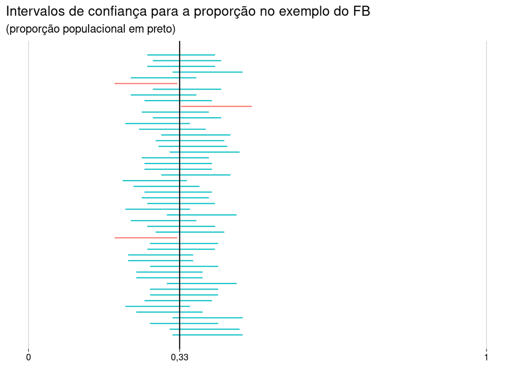

- Ah, e agora você sabe qual era o valor de $p$. Volte e veja se aquele primeiro intervalo de confiança era bom.
- Pense e responda: os intervalos de confiança da figura acima têm todos o mesmo tamanho?

# 2 No geral

## 2.1 Situação

- Você tem uma amostra de $n$ elementos, com proporção amostral $\hat p$.
- Você quer construir um intervalo de confiança de $c \%$ para a proporção populacional.

No nosso exemplo, $n = 156$, $\hat p = 48/156$ e $c = 0.95$.

## 2.2 Verificar as condições para usar o TCL

- A distribuição da população é normal e $n \geq 10$?
- Caso a distribuição da população não seja conhecida, $n \geq 30$?
- A amostra é aleatória, representativa da população?
- Os valores da amostra são independentes entre si?
- O tamanho da amostra é menos do que $10\%$ da população?
- Há pelo menos $10$ fracassos e pelo menos $10$ sucessos na amostra?

## 2.3 Calcular o erro padrão da distribuição amostral de $\hat p$

$$EP = \sqrt{\frac{\hat p (1 - \hat p)}{n}}$$

## 2.4 Calcular a margem de erro

- Calcular o valor crítico $z^\star$: o valor tal que a área abaixo da curva normal padrão entre $-z^\star$ e $z^\star$ seja de $c$

  ```r
  z <- -qnorm((1 - c)/2)
  ```

- No nosso exemplo, `z = -qnorm(0.025) = 1,96`.
- A margem de erro vai ser

  $$ME = z^\star \cdot EP$$

## 2.5 Construir o intervalo

- O intervalo de confiança será

  $$[\quad \hat p - ME \quad,\quad \hat p + ME \quad]$$

## 2.6 Outros níveis de confiança

- No exemplo, usamos $c = 95\%$.
- O que acontece quando $c = 90\%$?
- E quando $c = 99\%$?
- Refaça o exemplo usando estes valores. Os intervalos ficam maiores? Menores? Qual a relação entre o nível de confiança $c$ e o tamanho da margem de erro?
- O que aconteceria se o nível de confiança fosse de $100\%$? Nós saberíamos a proporção populacional com certeza?

# 3 Escolhendo o tamanho da amostra

## 3.1 Exemplo

- Você quer fazer uma pesquisa para saber a proporção $p$ da população do seu estado que vai votar no candidato $A$ na próxima eleição.
- Você quer que a margem de erro seja de $5$ pontos percentuais (i.e., $ME = 0{,}05$), com $95\%$ de confiança.
- Qual deve ser o tamanho $n$ da sua amostra?
- Pelo que vimos na seção anterior

  $$ME \quad=\quad z^\star \cdot EP \quad=\quad z^\star \cdot \sqrt{\frac{\hat p (1 - \hat p)}{n}}$$
- Nós podemos isolar $n$ e chegar a (confira)

  $$n = \hat p (1-\hat p) \left(\frac{z^\star}{ME}\right)^2$$
- Nós temos $ME = 0{,}05$ e $z^\star = 1{,}96$ (calculado a partir do nível de confiança).
- E $\hat p$? Bem, o pior caso é o valor de $\hat p$ que maximiza $n$, que é $\hat p = 0{,}5$.
- Com estes valores, chegamos a

$$n = 0{,}5 \cdot 0{,}5 \cdot \left(\frac{1{,}96}{0{,}05}\right)^2 = 384{,}16$$

- Conclusão: precisamos de uma amostra de pelo menos $385$ pessoas.
- Perceba que usamos o valor de pior caso para $\hat p$. Se já tivermos uma estimativa para $\hat p$ (obtida de uma pesquisa anterior, por exemplo), podemos usar esta estimativa e obter um valor menor para $n$.
- Perceba, também, que o tamanho da população não entra em jogo, a não ser para verificar que a amostra é menos do que $10\%$ da população.
- Calcule, por exemplo, qual seria o valor de $n$ se já tivéssemos uma estimativa de $\hat p = 0{,}3$.

# 4 Em R

## 4.1 Usando `binom.test`

- Tudo isto já é feito pelo R base, com a função `binom.test`, embora o algoritmo seja um pouco diferente, como você pode ver pelos resultados:

  ```r
  bt <- binom.test(48, 156)
  bt
  ```

  ```
  ##
  ##  Exact binomial test
  ##
  ## data:  48 and 156
  ## number of successes = 48, number of trials = 156, p-value = 0,000001748
  ## alternative hypothesis: true probability of success is not equal to 0,5
  ## 95 percent confidence interval:
  ##  0,2363644 0,3864933
  ## sample estimates:
  ## probability of success
  ##              0,3076923
  ```

- Esta função, além de computar o intervalo de confiança, faz um *teste de hipótese* (assunto de uma aula futura).
- O valor de retorno desta função é uma lista:

  ```r
  str(bt)
  ```

  ```
  ## List of 9
  ##  $ statistic  : Named num 48
  ##   ..- attr(*, "names")= chr "number of successes"
  ##  $ parameter  : Named num 156
  ##   ..- attr(*, "names")= chr "number of trials"
  ##  $ p.value    : num 0,00000175
  ##  $ conf.int   : num [1:2] 0,236 0,386
  ##   ..- attr(*, "conf.level")= num 0,95
  ##  $ estimate   : Named num 0,308
  ##   ..- attr(*, "names")= chr "probability of success"
  ##  $ null.value : Named num 0,5
  ##   ..- attr(*, "names")= chr "probability of success"
  ##  $ alternative: chr "two.sided"
  ##  $ method     : chr "Exact binomial test"
  ##  $ data.name  : chr "48 and 156"
  ##  - attr(*, "class")= chr "htest"
  ```

- Se você quiser só o intervalo de confiança:

  ```r
  bt$conf.int
  ```

  ```
  ## [1] 0,2363644 0,3864933
  ## attr(,"conf.level")
  ## [1] 0,95
  ```

## 4.2 Usando o pacote `binom`

- Na verdade, existem muitos algoritmos diferentes para construir um intervalo de confiança para a proporção. [Este artigo, de 2013](https://www.ucl.ac.uk/english-usage/staff/sean/resources/binomialpoisson.pdf), examina diversas alternativas.
- O pacote `binom` implementa vários destes algoritmos através da função `binom.confint`:

  ```r
  library(binom)

  binom.confint(48, 156) %>%
    kbl(format.args = list(big.mark = '.')) %>%
    kable_paper(
      c('striped', 'hover'),
      full_width = FALSE
    )
  ```

  | method | x | n | mean | lower | upper |
  | --- | --- | --- | --- | --- | --- |
  | agresti-coull | 48 | 156 | 0,3076923 | 0,2404694 | 0,3841586 |
  | asymptotic | 48 | 156 | 0,3076923 | 0,2352664 | 0,3801182 |
  | bayes | 48 | 156 | 0,3089172 | 0,2377481 | 0,3814466 |
  | cloglog | 48 | 156 | 0,3076923 | 0,2371200 | 0,3808746 |
  | exact | 48 | 156 | 0,3076923 | 0,2363644 | 0,3864933 |
  | logit | 48 | 156 | 0,3076923 | 0,2403194 | 0,3843959 |
  | probit | 48 | 156 | 0,3076923 | 0,2393586 | 0,3834481 |
  | profile | 48 | 156 | 0,3076923 | 0,2388119 | 0,3828426 |
  | lrt | 48 | 156 | 0,3076923 | 0,2388381 | 0,3828590 |
  | prop.test | 48 | 156 | 0,3076923 | 0,2376901 | 0,3873412 |
  | wilson | 48 | 156 | 0,3076923 | 0,2406146 | 0,3840134 |

- O algoritmo que descrevemos no exemplo é o `asymptotic`.
- O algoritmo implementado por `binom.test` é o `exact`.
- Leia as páginas de ajuda de `binom.test` e de `binom.confint`.
- No RStudio, use `Code | Go To Function Definition` na chamada da função `binom.confint` para ver o seu código fonte. O método `asymptotic` é implementado nas linhas $45$–$54$, usando variáveis definidas nas linhas $28$–$32$. Lendo o código, você deve ser capaz de perceber que o que está acontecendo é o mesmo que fizemos no nosso exemplo.